# Econ 320: Python Assignment 3

## Multicolinearity detection and output presentation

## Package setup

```python
# Import necessary packages here
import wooldridge as woo
import numpy as np
import pandas as pd
import seaborn as sns
import matplotlib.pyplot as plt
from stargazer.stargazer import Stargazer
from IPython.core.display import HTML
import statsmodels.formula.api as smf
# for the VIF
import statsmodels.stats.outliers_influence as smo
import patsy as pt
```

## Initial setup and correlation matrix

Using the data `gpa1` from the Wooldridge package, create two new variables

$$x = 3+ ACT*2$$

$$z=ACT+2*hsGPA$$

Create a correlation matrix of `colGPA`, `hsGPA`, `ACT`, `x`, `z`, and a correlation matrix graph

What can you say about the correlation matrix and the graphs?

**Observation**

- *We can notice that the variables ACT and x, ACT and z, as well as x and z are all strongly correlated.*

```python
# load the data
gpa1 = woo.dataWoo('gpa1')

# Generate the variables x and z as part of the data gpa1
gpa1['x'] = 3 + 2 * gpa1['ACT']
gpa1['z'] = gpa1['ACT'] + 2 * gpa1['hsGPA']

# correlation matrix

cormat = gpa1[["colGPA","hsGPA","ACT","x","z"]]

cormat.corr().round(decimals=2)
```

|  | colGPA | hsGPA | ACT | x | z |
| --- | --- | --- | --- | --- | --- |
| colGPA | 1.00 | 0.41 | 0.21 | 0.21 | 0.27 |
| hsGPA | 0.41 | 1.00 | 0.35 | 0.35 | 0.52 |
| ACT | 0.21 | 0.35 | 1.00 | 1.00 | 0.98 |
| x | 0.21 | 0.35 | 1.00 | 1.00 | 0.98 |
| z | 0.27 | 0.52 | 0.98 | 0.98 | 1.00 |

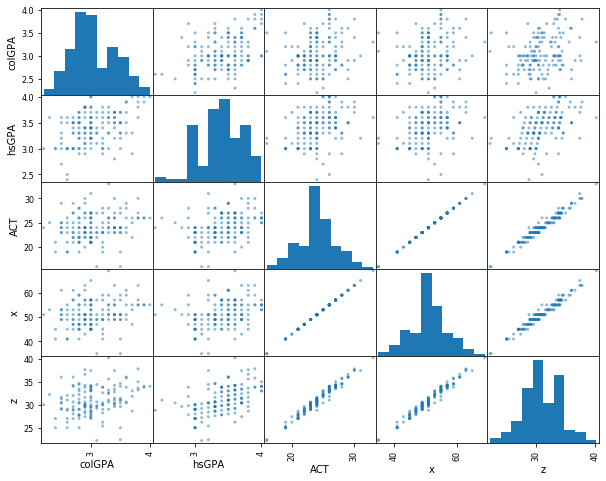

```python
# Correlation graphs
pd.plotting.scatter_matrix(cormat, alpha=0.5, figsize=(10, 8));
```

## Run the following three regressions and show them all together in a nice looking table.

$$colGPA=\beta_0 + \beta_1hsGPA + \beta_2ACT + u $$$$colGPA=\beta_0 + \beta_1hsGPA + \beta_2ACT + + \beta_3x + \beta_4z + u $$$$colGPA=\beta_0 + \beta_1hsGPA + \beta_2ACT + \beta_3age+ \beta_4alcohol + u $$

Make a summary of the second regression, look at it. ( Then comment this code by using #) Then make sure that the output of the code for it doesn't show, this is just for you to see how Python reacts to the multicolinearity problem. EXPLAIN what happened to the output and why.

**Explanation**

- *The warning suggests that there might be strong multicollinearity problems, which is true because the variables x, z, and ACT are strongly correlated due to the way x and z were created: we created the variable z using a linear combination of ACT and hsGPA; the variable x is created as a function of ACT.*

Put both results in a nice looking table.

```python
# model 1
model1 = smf.ols(formula='colGPA ~ hsGPA + ACT ', data=gpa1).fit()

model1.summary()
```

OLS Regression Results

| Dep. Variable: | colGPA | R-squared: | 0.176 |
| --- | --- | --- | --- |
| Model: | OLS | Adj. R-squared: | 0.164 |
| Method: | Least Squares | F-statistic: | 14.78 |
| Date: | Sat, 27 Mar 2021 | Prob (F-statistic): | 1.53e-06 |
| Time: | 12:58:15 | Log-Likelihood: | -46.573 |
| No. Observations: | 141 | AIC: | 99.15 |
| Df Residuals: | 138 | BIC: | 108.0 |
| Df Model: | 2 |  |  |
| Covariance Type: | nonrobust |  |  |

|  | coef | std err | t | P>\|t\| | [0.025 | 0.975] |
| --- | --- | --- | --- | --- | --- | --- |
| Intercept | 1.2863 | 0.341 | 3.774 | 0.000 | 0.612 | 1.960 |
| hsGPA | 0.4535 | 0.096 | 4.733 | 0.000 | 0.264 | 0.643 |
| ACT | 0.0094 | 0.011 | 0.875 | 0.383 | -0.012 | 0.031 |

| Omnibus: | 3.056 | Durbin-Watson: | 1.885 |
| --- | --- | --- | --- |
| Prob(Omnibus): | 0.217 | Jarque-Bera (JB): | 2.469 |
| Skew: | 0.199 | Prob(JB): | 0.291 |
| Kurtosis: | 2.488 | Cond. No. | 298. |

Warnings:  
[1] Standard Errors assume that the covariance matrix of the errors is correctly specified.

```python
#model 2
model2 = smf.ols(formula = "colGPA ~ hsGPA+ACT+x+z",data=gpa1).fit()

#model2.summary()
```

```python
# model 3
model3 = smf.ols(formula="colGPA~hsGPA+ACT+age+alcohol",data=gpa1).fit()
model3.summary()
```

OLS Regression Results

| Dep. Variable: | colGPA | R-squared: | 0.185 |
| --- | --- | --- | --- |
| Model: | OLS | Adj. R-squared: | 0.161 |
| Method: | Least Squares | F-statistic: | 7.735 |
| Date: | Sat, 27 Mar 2021 | Prob (F-statistic): | 1.20e-05 |
| Time: | 12:58:15 | Log-Likelihood: | -45.805 |
| No. Observations: | 141 | AIC: | 101.6 |
| Df Residuals: | 136 | BIC: | 116.4 |
| Df Model: | 4 |  |  |
| Covariance Type: | nonrobust |  |  |

|  | coef | std err | t | P>\|t\| | [0.025 | 0.975] |
| --- | --- | --- | --- | --- | --- | --- |
| Intercept | 0.6016 | 0.667 | 0.902 | 0.369 | -0.718 | 1.921 |
| hsGPA | 0.4862 | 0.100 | 4.873 | 0.000 | 0.289 | 0.683 |
| ACT | 0.0086 | 0.011 | 0.778 | 0.438 | -0.013 | 0.030 |
| age | 0.0278 | 0.023 | 1.182 | 0.239 | -0.019 | 0.074 |
| alcohol | 0.0074 | 0.021 | 0.346 | 0.730 | -0.035 | 0.050 |

| Omnibus: | 3.772 | Durbin-Watson: | 1.833 |
| --- | --- | --- | --- |
| Prob(Omnibus): | 0.152 | Jarque-Bera (JB): | 2.602 |
| Skew: | 0.159 | Prob(JB): | 0.272 |
| Kurtosis: | 2.416 | Cond. No. | 753. |

Warnings:  
[1] Standard Errors assume that the covariance matrix of the errors is correctly specified.

### ⚠️ After looking at the results from your regressions, Model 2 presented a particular warning. What does it say?

- *The warning suggests that there might be strong multicollinearity problems*

## Given the multicolinearity concern (because of our added variables), let's ignore that model and now put the results from Model 1 and 3 into a stargazer table.

```python
# use stargazer to view the OLS outputs
st=Stargazer([model1,model3])
st.rename_covariates({'hsGPA': 'High SchoolGPA'})
st.covariate_order(["hsGPA","ACT", "age","alcohol","Intercept"])
from IPython.core.display import HTML
HTML(st.render_html())
```

|  | *Dependent variable:colGPA* |  |
| --- | --- | --- |
|  | (1) | (2) |
| High SchoolGPA | 0.453*** | 0.486*** |
|  | (0.096) | (0.100) |
| ACT | 0.009 | 0.009 |
|  | (0.011) | (0.011) |
| age |  | 0.028 |
|  |  | (0.023) |
| alcohol |  | 0.007 |
|  |  | (0.021) |
| Intercept | 1.286*** | 0.602 |
|  | (0.341) | (0.667) |
| Observations | 141 | 141 |
| R<sup>2</sup> | 0.176 | 0.185 |
| Adjusted R<sup>2</sup> | 0.164 | 0.161 |
| Residual Std. Error | 0.340 (df=138) | 0.341 (df=136) |
| F Statistic | 14.781*** (df=2; 138) | 7.735*** (df=4; 136) |
| Note: | *p<0.1; **p<0.05; ***p<0.01 |  |

## Calculate VIF and prove OLS properties

- Evaluate the vif of model1 and model2.
- See what happens to model2 when you run the code. Explain.

-The VIF for 4 of the variables in model 2 becomes infinite. This is resulted from strong strong multicollinearity between the variables in model 2, which consequently makes $R_j^{2}$ very approach 1 and $VIF_j$ approach infinity.

```python
# calculate VIF :
XX = gpa1[["colGPA","hsGPA","ACT"]].copy()
XX['Intercept'] = 1

# Compute and view VIF
vif = pd.DataFrame()
vif["variables"] = XX.columns
vif["VIF"] = [smo.variance_inflation_factor(XX.values, i) for i in range(XX.shape[1])]

vif
```

|  | variables | VIF |
| --- | --- | --- |
| 0 | colGPA | 1.214213 |
| 1 | hsGPA | 1.320178 |
| 2 | ACT | 1.142120 |
| 3 | Intercept | 156.017430 |

```python
# calculate VIF :
XX = gpa1[["colGPA","hsGPA","ACT","x","z"]].copy()
XX['Intercept'] = 1

# Compute and view VIF
vif = pd.DataFrame()
vif["variables"] = XX.columns
vif["VIF"] = [smo.variance_inflation_factor(XX.values, i) for i in range(XX.shape[1])]

vif
```

|  | variables | VIF |
| --- | --- | --- |
| 0 | colGPA | 1.214213 |
| 1 | hsGPA | inf |
| 2 | ACT | inf |
| 3 | x | inf |
| 4 | z | inf |
| 5 | Intercept | 0.000000 |

## Demonstrate that the residuals of model1 add up to zero. What does that mean? EXPLAIN.

- *This means that the regression line is the line of best fit. The sum of residuals should be always equal to zero for a regression line that does not pass through the origin: it follows immediately from the first-order condition of the OLS model that $\sum \hat u_i = 0$.*

```python
#find the sum of the residulas in model 1
print( 'Sum of residuals Model 1 :', abs(round(model1.resid.sum(),3)))
```

```
Sum of residuals Model 1 : 0.0
```

## Demonstrate that the $R^2$ of a regression of the residuals of model1 on the original regressors must be zero. What does this mean? EXPLAIN.

- *This means that 0% of the variation in $\hat u$ is explained by the original regressors, which indicates that $\hat u$ and the original regressors are not correlated.*

```python
# run regression of residuals on the regressors
gpa1['u_hat'] = model1.resid
reg = smf.ols(formula = 'u_hat ~ hsGPA + ACT', data = gpa1).fit()
print( 'R2 of residuals Model 1 :', abs(round(reg.rsquared,3)))
```

```
R2 of residuals Model 1 : 0.0
```

```python
!jupyter nbconvert --to html Econ320Lab_Assign3_Saier(Sam)Hu
```

```
[NbConvertApp] Converting notebook Econ320Lab_Assign3_Saier(Sam)Hu.ipynb to html
[NbConvertApp] Writing 422250 bytes to Econ320Lab_Assign3_Saier(Sam)Hu.html
```

**Packages used in this document** `wooldridge` `matplot.lib` `pandas` `numpy` `seaborn`

ECON220 Python Programming Laboratory

Professor *Paloma Lopez de mesa Moyano*

*paloma.moyano@emory.edu*

Department of Economics

Emory University